# Lecture 4: Model Selection

**Can I trust you?**

Joaquin Vanschoren

## Evaluation

- To know whether we can *trust* our method or system, we need to evaluate it.
- Model selection: choose between different models in a data-driven way.
  - If you cannot measure it, you cannot improve it.
- Convince others that your work is meaningful
  - Peers, leadership, clients, yourself(!)
- When possible, try to *interpret* what your model has learned
  - The signal your model found may just be an artifact of your biased data
  - See 'Why Should I Trust You?' by Marco Ribeiro et al.

[figure not shown]

### Designing Machine Learning systems

- Just running your favourite algorithm is usually not a great way to start
- Consider the problem: How to measure success? Are there costs involved?
  - Do you want to understand phenomena or do black box modelling?
- Analyze your model's mistakes. Don't just finetune endlessly.
  - Build early prototypes. Should you collect more, or additional data?
  - Should the task be reformulated?
- Overly complex machine learning systems are hard to maintain
  - See 'Machine Learning: The High Interest Credit Card of Technical Debt'

[figure not shown]

### Real world evaluations

- Evaluate predictions, but also how outcomes improve *because of them*
- Beware of feedback loops: predictions can influence future input data
  - Medical recommendations, spam filtering, trading algorithms,...
- Evaluate algorithms *in the wild*.
  - A/B testing: split users in groups, test different models in parallel
  - Bandit testing: gradually direct more users to the winning system

[figure not shown]

## Performance estimation techniques

- Always evaluate models *as if they are predicting future data*
- We do not have access to future data, so we pretend that some data is hidden
- Simplest way: the *holdout* (simple train-test split)
  - *Randomly* split data (and corresponding labels) into training and test set (e.g. 75%-25%)
  - Train (fit) a model on the training data, score on the test data

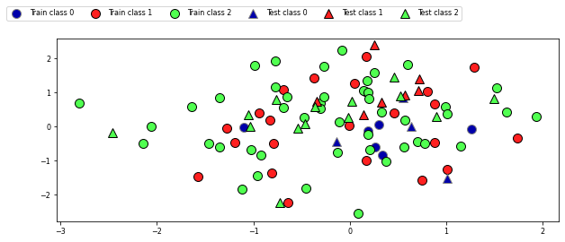

### K-fold Cross-validation

- Each random split can yield very different models (and scores)
  - e.g. all easy (of hard) examples could end up in the test set
- Split data into *k* equal-sized parts, called *folds*
  - Create *k* splits, each time using a different fold as the test set
- Compute *k* evaluation scores, aggregate afterwards (e.g. take the mean)
- Examine the score variance to see how *sensitive* (unstable) models are
- Large *k* gives better estimates (more training data), but is expensive

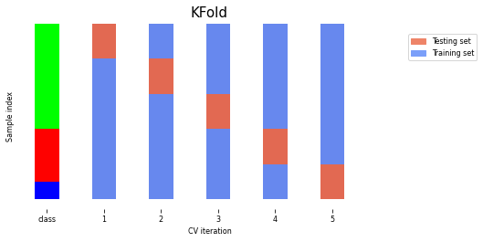

Can you explain this result?

```
kfold = KFold(n_splits=3)
cross_val_score(logistic_regression, iris.data, iris.target, cv=kfold)
```

```
Cross-validation scores KFold(n_splits=3):
[0. 0. 0.]
```

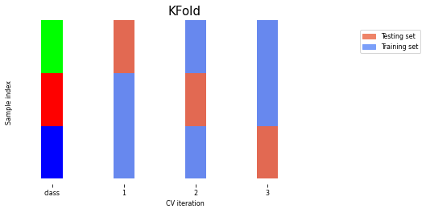

#### Stratified K-Fold cross-validation

- If the data is unbalanced, some classes have only few samples
- Likely that some classes are not present in the test set
- Stratification: *proportions* between classes are conserved in each fold
  - Order examples per class
  - Separate the samples of each class in *k* sets (strata)
  - Combine corresponding strata into folds

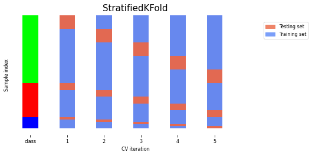

#### Leave-One-Out cross-validation

- *k* fold cross-validation with *k* equal to the number of samples
- Completely unbiased (in terms of data splits), but computationally expensive
- Actually generalizes *less* well towards unseen data
  - The training sets are correlated (overlap heavily)
  - Overfits on the data used for (the entire) evaluation
  - A different sample of the data can yield different results
- Recommended only for small datasets

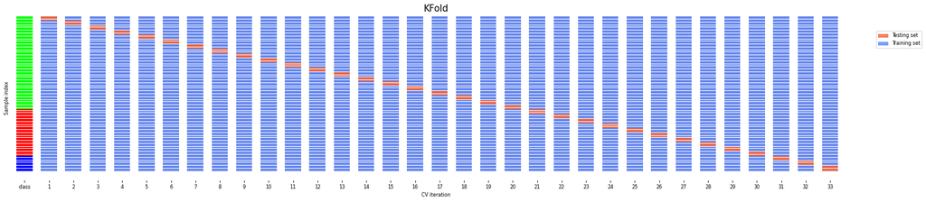

#### Shuffle-Split cross-validation

- Shuffles the data, samples (`train_size`) points randomly as the training set
- Can also use a smaller (`test_size`), handy with very large datasets
- Never use if the data is ordered (e.g. time series)

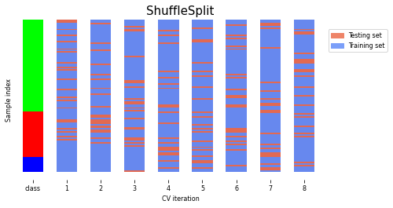

### The Bootstrap

- Sample *n* (dataset size) data points, with replacement, as training set (the bootstrap)
  - On average, bootstraps include 66% of all data points (some are duplicates)
- Use the unsampled (out-of-bootstrap) samples as the test set
- Repeat $k$ times to obtain $k$ scores
- Similar to Shuffle-Split with `train_size=0.66`, `test_size=0.34` but without duplicates

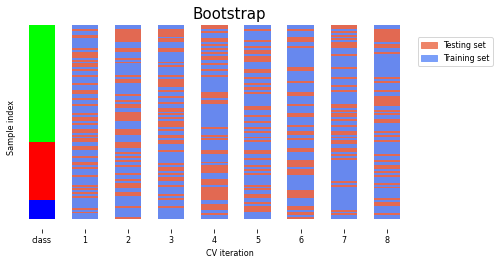

### Repeated cross-validation

- Cross-validation is still biased in that the initial split can be made in many ways
- Repeated, or n-times-k-fold cross-validation:
  - Shuffle data randomly, do k-fold cross-validation
  - Repeat n times, yields n times k scores
- Unbiased, very robust, but n times more expensive

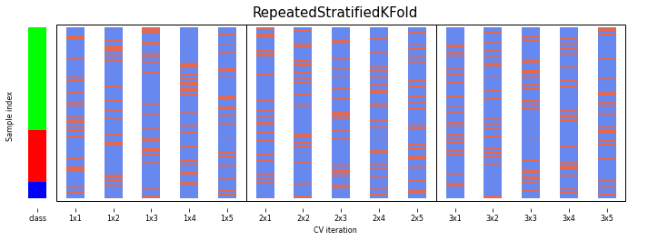

### Cross-validation with groups

- Sometimes the data contains inherent groups:
  - Multiple samples from same patient, images from same person,...
- Data from the same person may end up in the training *and* test set
- We want to measure how well the model generalizes to *other* people
- Make sure that data from one person are in *either* the train or test set
  - This is called *grouping* or *blocking*
  - Leave-one-subject-out cross-validation: test set for each subject/group

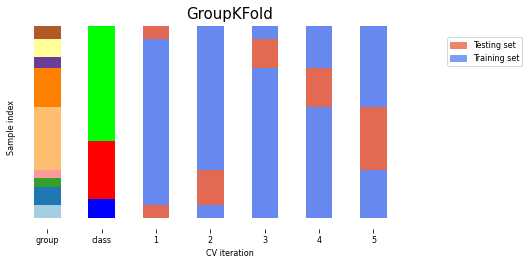

### Time series

When the data is ordered, random test sets are not a good idea

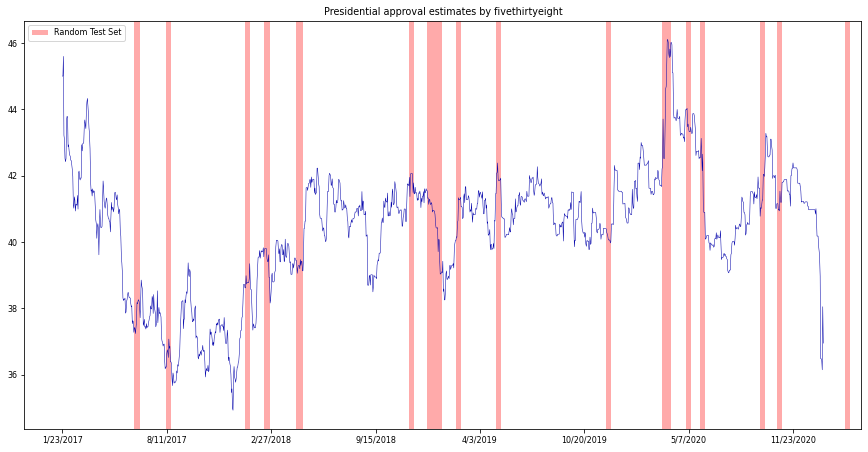

#### Test-then-train (prequential evaluation)

- Every new sample is evaluated only once, then added to the training set
  - Can also be done in batches (of *n* samples at a time)
- `TimeSeriesSplit`
  - In the kth split, the first k folds are the train set and the (k+1)th fold as the test set
  - Often, a maximum training set size (or window) is used
    - more robust against concept drift (change in data over time)

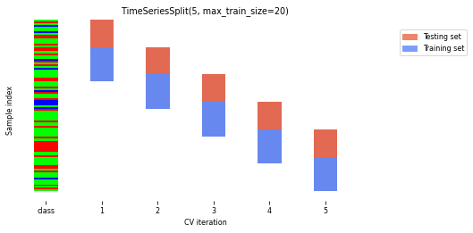

### Choosing a performance estimation procedure

No strict rules, only guidelines:

- Always use stratification for classification (sklearn does this by default)
- Use holdout for very large datasets (e.g. >1.000.000 examples)
  - Or when learners don't always converge (e.g. deep learning)
- Choose *k* depending on dataset size and resources
  - Use leave-one-out for very small datasets (e.g. <100 examples)
  - Use cross-validation otherwise
    - Most popular (and theoretically sound): 10-fold CV
    - Literature suggests 5x2-fold CV is better
- Use grouping or leave-one-subject-out for grouped data
- Use train-then-test for time series

## Evaluation Metrics for Classification

### Evaluation vs Optimization

- Each algorithm optimizes a given objective function (on the training data)
  - E.g. remember L2 loss in Ridge regression $$\mathcal{L}_{Ridge} = \sum_{n=1}^{N} (y_n-(\mathbf{w}\mathbf{x_n} + w_0))^2 + \alpha \sum_{i=0}^{p} w_i^2$$
- The choice of function is limited by what can be efficiently optimized
- However, we *evaluate* the resulting model with a score that makes sense **in the real world**
  - Percentage of correct predictions (on a test set)
  - The actual cost of mistakes (e.g. in money, time, lives,...)
- We also tune the algorithm's hyperparameters to maximize that score

### Binary classification

- We have a positive and a negative class
- 2 different kind of errors:
  - False Positive (type I error): model predicts positive while true label is negative
  - False Negative (type II error): model predicts negative while true label is positive
- They are not always equally important
  - Which side do you want to err on for a medical test?

[figure not shown]

#### Confusion matrices

- We can represent all predictions (correct and incorrect) in a confusion matrix
  - n by n array (n is the number of classes)
  - Rows correspond to true classes, columns to predicted classes
  - Count how often samples belonging to a class C are classified as C or any other class.
  - For binary classification, we label these true negative (TN), true positive (TP), false negative (FN), false positive (FP)

|  | Predicted Neg | Predicted Pos |
| --- | --- | --- |
| Actual Neg | TN | FP |
| Actual Pos | FN | TP |

```
confusion_matrix(y_test, y_pred):
 [[48  5]
 [ 5 85]]
```

#### Predictive accuracy

- Accuracy can be computed based on the confusion matrix
- Not useful if the dataset is very imbalanced
  - E.g. credit card fraud: is 99.99% accuracy good enough?

\begin{equation} \text{Accuracy} = \frac{\text{TP} + \text{TN}}{\text{TP} + \text{TN} + \text{FP} + \text{FN}} \end{equation}

- 3 models: very different predictions, same accuracy:

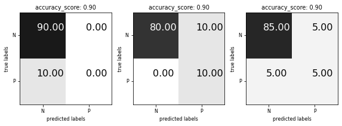

#### Precision

- Use when the goal is to limit FPs
  - Clinical trails: you only want to test drugs that really work
  - Search engines: you want to avoid bad search results

\begin{equation} \text{Precision} = \frac{\text{TP}}{\text{TP} + \text{FP}} \end{equation}

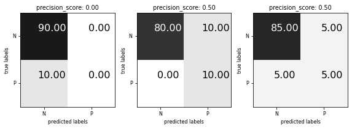

#### Recall

- Use when the goal is to limit FNs
  - Cancer diagnosis: you don't want to miss a serious disease
  - Search engines: You don't want to omit important hits
- Also know as sensitivity, hit rate, true positive rate (TPR)

\begin{equation} \text{Recall} = \frac{\text{TP}}{\text{TP} + \text{FN}} \end{equation}

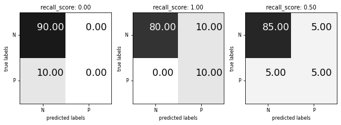

**Comparison**

[figure not shown]

#### F1-score

- Trades off precision and recall:

\begin{equation} \text{F1} = 2 \cdot \frac{\text{precision} \cdot \text{recall}}{\text{precision} + \text{recall}} \end{equation}

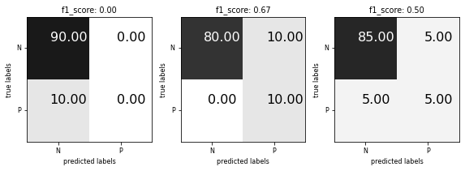

**Classification measure Zoo**

[figure not shown]

https://en.wikipedia.org/wiki/Precision_and_recall

### Multi-class classification

- Train models *per class* : one class viewed as positive, other(s) als negative, then average
  - micro-averaging: count total TP, FP, TN, FN (every sample equally important)
    - micro-precision, micro-recall, micro-F1, accuracy are all the same $$\text{Precision:} \frac{\sum_{c=1}^C\text{TP}_c}{\sum_{c=1}^C\text{TP}_c + \sum_{c=1}^C\text{FP}_c} \xrightarrow{c=2} \frac{\text{TP} + \text{TN}}{\text{TP} + \text{TN} + \text{FP} + \text{FN}}$$
  - macro-averaging: average of scores $R(y_c,\hat{y_c})$ obtained on each class
    - Preferable for imbalanced classes (if all classes are equally important)
    - macro-averaged recall is also called *balanced accuracy* $$\frac{1}{C} \sum_{c=1}^C R(y_c,\hat{y_c})$$
  - weighted averaging ($w_c$: ratio of examples of class $c$, aka support): $\sum_{c=1}^C w_c R(y_c,\hat{y_c})$

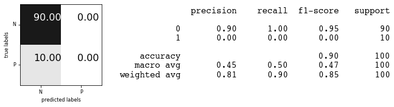

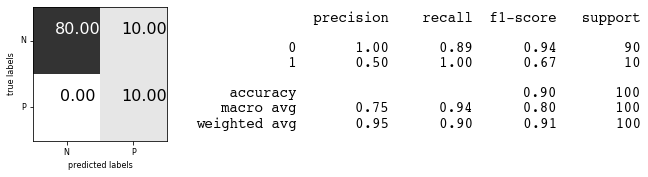

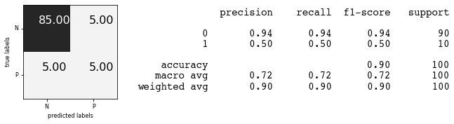

### Other useful classification metrics

- Cohen's Kappa
  - Measures 'agreement' between different models (aka inter-rater agreement)
  - To evaluate a single model, compare it against a model that does random guessing
    - Similar to accuracy, but taking into account the possibility of predicting the right class by chance
  - Can be weighted: different misclassifications given different weights
  - 1: perfect prediction, 0: random prediction, negative: worse than random
  - With $p_0$ = accuracy, and $p_e$ = accuracy of random classifier: $$\kappa = \frac{p_o - p_e}{1 - p_e}$$
- Matthews correlation coefficient
  - Corrects for imbalanced data, alternative for balanced accuracy or AUROC
  - 1: perfect prediction, 0: random prediction, -1: inverse prediction $$MCC = \frac{tp \times tn - fp \times fn}{\sqrt{(tp + fp)(tp + fn)(tn + fp)(tn + fn)}}$$

## Probabilistic evaluation

- Classifiers can often provide uncertainty estimates of predictions.
- Remember that linear models actually return a numeric value.
  - When $\hat{y}<0$, predict class -1, otherwise predict class +1 $$\hat{y} = w_0 * x_0 + w_1 * x_1 + ... + w_p * x_p + b $$
- In practice, you are often interested in how certain a classifier is about each class prediction (e.g. cancer treatments).
- Most learning methods can return at least one measure of *confidence* in their predicions.
  - Decision function: floating point value for each sample (higher: more confident)
  - Probability: estimated probability for each class

### The decision function

In the binary classification case, the return value of the decision function encodes how strongly the model believes a data point belongs to the “positive” class.

- Positive values indicate preference for the positive class.
- The range can be arbitrary, and can be affected by hyperparameters. Hard to interpret.

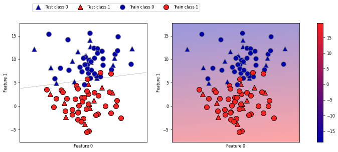

### Predicting probabilities

Some models can also return a *probability* for each class with every prediction. These sum up to 1. We can visualize them again. Note that the gradient looks different now.

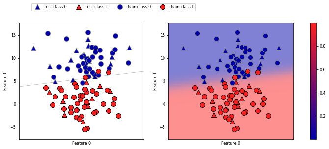

### Threshold calibration

- By default, we threshold at 0 for `decision_function` and 0.5 for `predict_proba`
- Depending on the application, you may want to threshold differently
  - Lower threshold yields fewer FN (better recall), more FP (worse precision), and vice-versa

```
interactive(children=(FloatSlider(value=2.220446049250313e-16, description='threshold', max=1.3, min=-1.2), Ou…
```

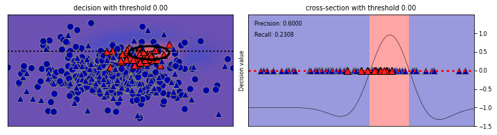

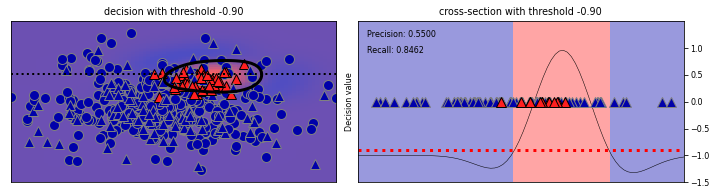

### Precision-Recall curve

- The best trade-off between precision and recall depends on your application
  - You can have arbitrary high recall, but you often want reasonable precision, too.
- Plotting precision against recall *for all possible thresholds* yields a **precision-recall curve**
  - Change the treshold until you find a sweet spot in the precision-recall trade-off
  - Often jagged at high thresholds, when there are few positive examples left

```
interactive(children=(FloatSlider(value=-0.9899999999999998, description='threshold', max=1.4, min=-3.19), Dro…
```

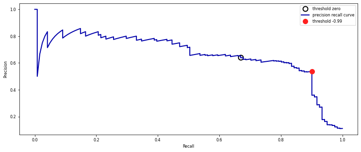

#### Model selection

- Some models can achieve trade-offs that others can't
- Your application may require very high recall (or very high precision)
  - Choose the model that offers the best trade-off, given your application
- The area under the PR curve (AUPRC) gives the *best overall* model

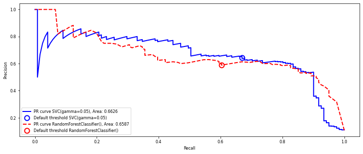

#### Hyperparameter effects

Of course, hyperparameters affect predictions and hence also the shape of the curve

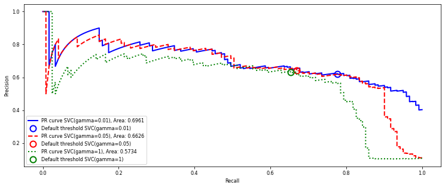

### Receiver Operating Characteristics (ROC)

- Trade off *true positive rate* $\textit{TPR}= \frac{TP}{TP + FN}$ with *false positive rate* $\textit{FPR} = \frac{FP}{FP + TN}$
- Plotting TPR against FPR *for all possible thresholds* yields a *Receiver Operating Characteristics curve*
  - Change the treshold until you find a sweet spot in the TPR-FPR trade-off
  - Lower thresholds yield higher TPR (recall), higher FPR, and vice versa

```
interactive(children=(FloatSlider(value=-0.9899999999999998, description='threshold', max=1.4, min=-3.19), Dro…
```

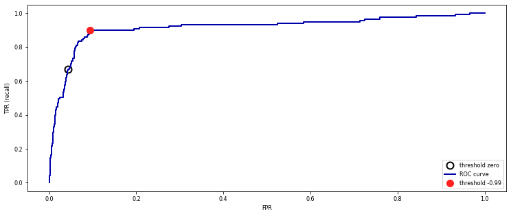

#### Visualization

- Histograms show the amount of points with a certain decision value (for each class)
- $\textit{TPR}= \frac{\color{red}{TP}}{\color{red}{TP} + \color{magenta}{FN}}$ can be seen from the positive predictions (top histogram)
- $\textit{FPR} = \frac{\color{cyan}{FP}}{\color{cyan}{FP} + \color{blue}{TN}}$ can be seen from the negative predictions (bottom histogram)

```
interactive(children=(FloatSlider(value=0.0, description='threshold', max=2.0, min=-2.0), Output()), _dom_clas…
```

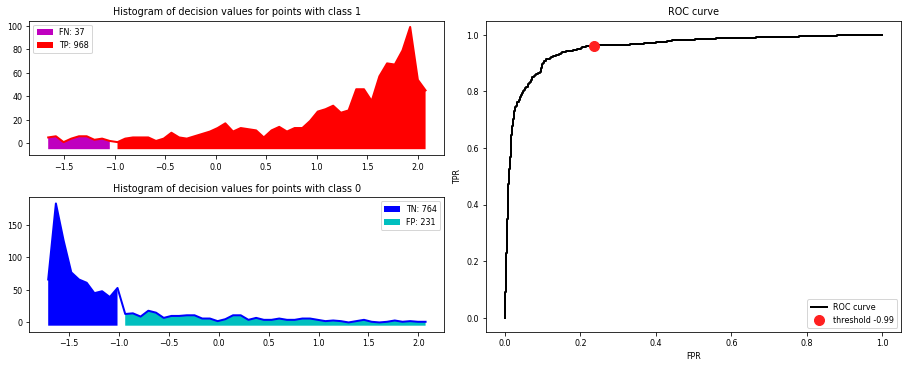

#### Model selection

- Again, some models can achieve trade-offs that others can't
- Your application may require minizing FPR (low FP), or maximizing TPR (low FN)
- The area under the ROC curve (AUROC or AUC) gives the *best overall* model
  - Frequently used for evaluating models on imbalanced data
  - Random guessing (TPR=FPR) or predicting majority class (TPR=FPR=1): 0.5 AUC

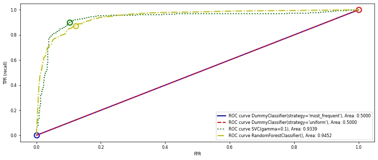

#### Multi-class AUROC (or AUPRC)

- We again need to choose between micro- or macro averaging TPR and FPR.
  - Micro-average if every sample is equally important (irrespective of class)
  - Macro-average if every class is equally important, especially for imbalanced data

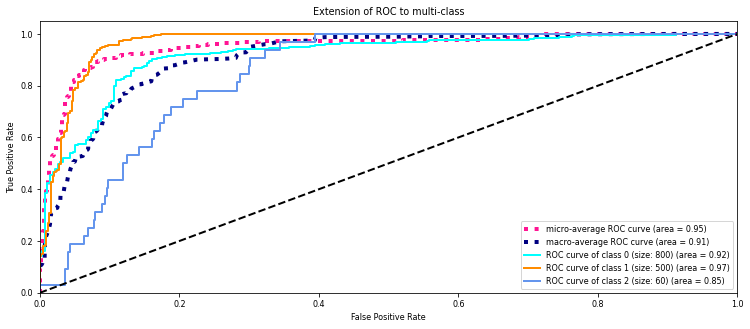